# Exam

Tristen Tooming

3/4/2021

## Assignment 1. Regression

The data set lakesurvey.csv contains 16 chemical and physical measurements from 2782 lakes in Scandinavia.

1. Variable selection Import the data into R. Set up a model where pH is the response and the rest of the variables are predictors. Perform Best subset selection and present the best models (selected variables and their regression coefficients) based on both BIC and Mallows Cp. The next task is to perform variable selection with the LASSO using the glmnet package. Tune the regularization parameter with 500-fold CV. Present a plot that shows that the minimum MSE has been obtained. Also present the selected variables and their regression coefficients. Compare and discuss the results from both analyses. (5p)

```r
lake = read.csv("lakesurvey.csv", header = T, sep = ' ')
str(lake)
```

```
## 'data.frame':    2782 obs. of  16 variables:
##  $ Temp     : num  4.4 3.8 5.4 5.5 3.8 4 2.7 5.8 2.9 1.8 ...
##  $ pH       : num  7.15 7.49 7.46 7.52 7.6 7.67 6.77 7.32 6.59 7.29 ...
##  $ Cond     : num  7.49 10.6 13.5 15.4 13.7 16.2 16.7 9.18 3.64 17.9 ...
##  $ Ca       : num  0.262 0.477 0.742 0.872 0.72 0.733 0.379 0.471 0.161 0.714 ...
##  $ Mg       : num  0.201 0.275 0.278 0.24 0.41 0.512 0.224 0.173 0.066 0.323 ...
##  $ Na       : num  0.231 0.243 0.322 0.44 0.259 0.392 0.923 0.216 0.095 0.666 ...
##  $ K        : num  0.031 0.049 0.051 0.04 0.045 0.058 0.024 0.027 0.007 0.051 ...
##  $ AlkAcid  : num  0.344 0.478 0.698 0.961 0.868 ...
##  $ SO4_IC   : num  0.132 0.276 0.251 0.165 0.261 0.197 0.125 0.246 0.108 0.217 ...
##  $ Cl       : num  0.193 0.241 0.334 0.415 0.242 ...
##  $ NO2NO3N  : int  105 70 209 31 34 88 79 39 7 16 ...
##  $ Tot.N_ps : int  591 321 569 678 648 653 511 350 288 654 ...
##  $ TotP     : int  22 29 42 37 24 34 29 23 8 24 ...
##  $ AbsF420nm: num  0.042 0.045 0.154 0.037 0.054 0.027 0.209 0.025 0.07 0.116 ...
##  $ TOC      : num  7.8 7.1 11 10.3 8.3 8.1 13.6 5.4 8 10.9 ...
##  $ Si       : num  1.09 1.17 3.54 0.96 1.37 1.19 3.42 1.42 0.19 1.7 ...
```

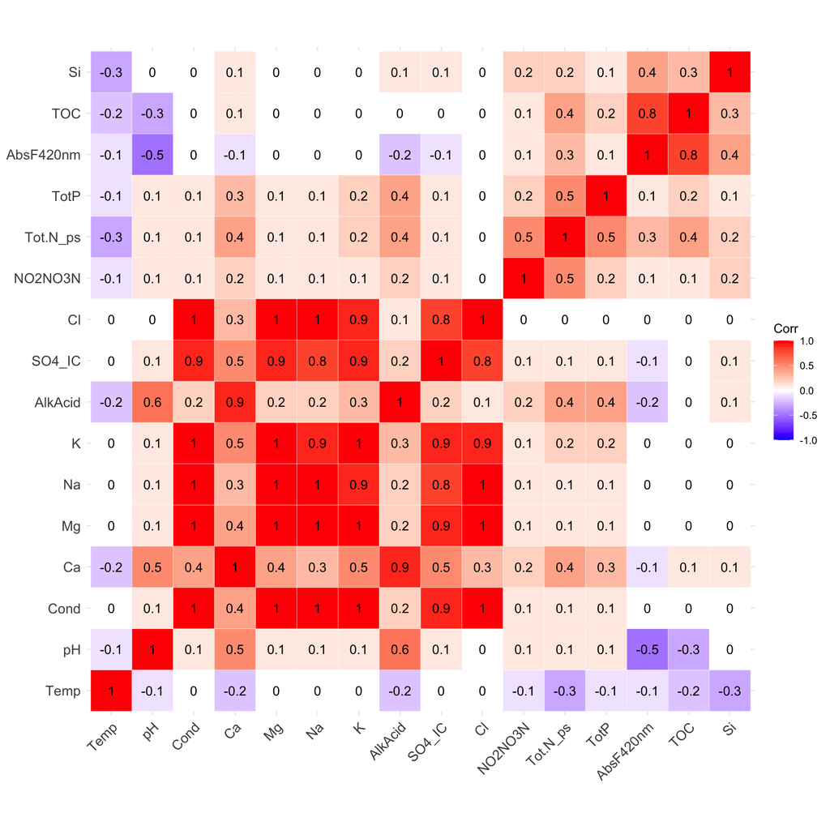

```r
library(ggcorrplot)
corr = round(cor(lake), 1)
ggcorrplot(corr, outline.color = "white",lab = T,lab_size =4)
```

**Best Subset Selection**

```r
library(ISLR)
library(leaps)
# Fit
# Showing only best (nbest = 1)
regfit.models <- regsubsets(pH~., data = lake, nbest = 1, nvmax = ncol(lake))

# Summary, Cp, BIC
res.sum <- summary(regfit.models)
as.data.frame(res.sum$outmat)
```

```
##           Temp Cond Ca Mg Na K AlkAcid SO4_IC Cl NO2NO3N Tot.N_ps TotP
## 1  ( 1 )                             *
## 2  ( 1 )                             *
## 3  ( 1 )                             *
## 4  ( 1 )                             *                               *
## 5  ( 1 )             *       *              *
## 6  ( 1 )             *  *  *                *
## 7  ( 1 )             *  *  *                *          *
## 8  ( 1 )             *  *  * *              *          *
## 9  ( 1 )             *  *  * *              *          *             *
## 10  ( 1 )         *  *  *  * *              *          *             *
## 11  ( 1 )            *  *  * *       *      *  *       *             *
## 12  ( 1 )         *  *  *  * *       *      *          *        *    *
## 13  ( 1 )         *  *  *  * *       *      *          *        *    *
## 14  ( 1 )         *  *  *  * *       *      *  *       *        *    *
```

[output cut: 17 more lines]

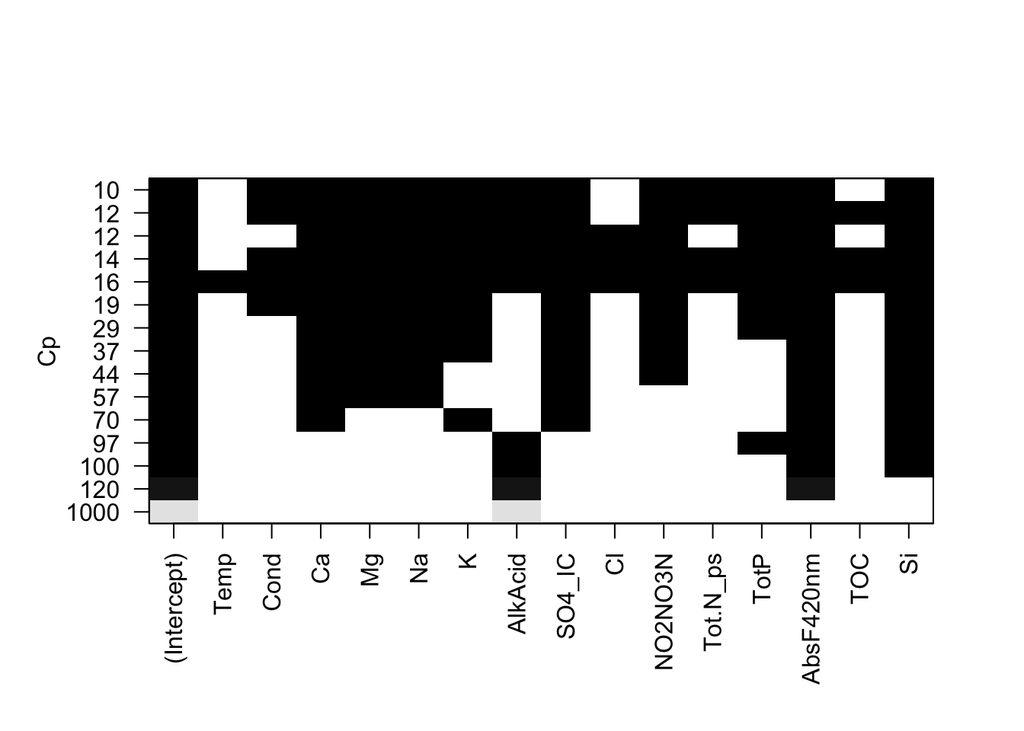

```r
plot(regfit.models, scale='Cp')
```

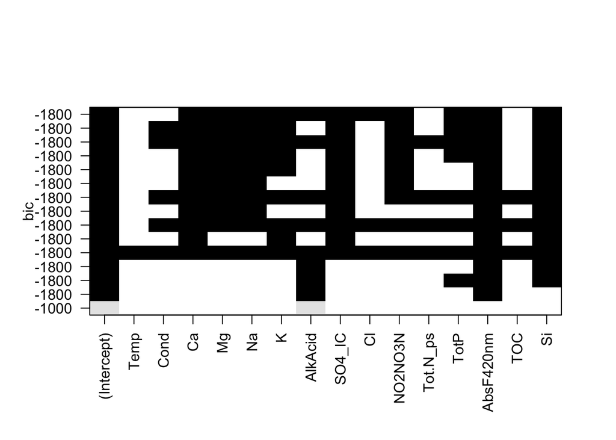

```
## Model with best Cp (10.34) model: 12
## Model: pH ~ (Intercept) + Cond + Ca + Mg + Na + K + AlkAcid + SO4_IC + NO2NO3N + Tot.N_ps + TotP + AbsF420nm + Si
##
## Model with best BIC (-1833.62) model: 11
## Model: pH ~ (Intercept) + Ca + Mg + Na + K + AlkAcid + SO4_IC + Cl + NO2NO3N + TotP + AbsF420nm + Si
```

```r
plot(regfit.models, scale='bic')
```

**Lasso**

```r
parameters <- c(seq(0.01, 0.1, by = 0.01))

model_lasso <- train(
  pH~., data = lake, method = "glmnet",
  scale = TRUE, # scale = TRUE for standardizing the variables to make them comparable.
  trControl = trainControl("LOOCV", number = 500),
  tuneGrid = expand.grid(alpha = 1,  lambda = parameters),
  metric = 'RMSE'
  )
```

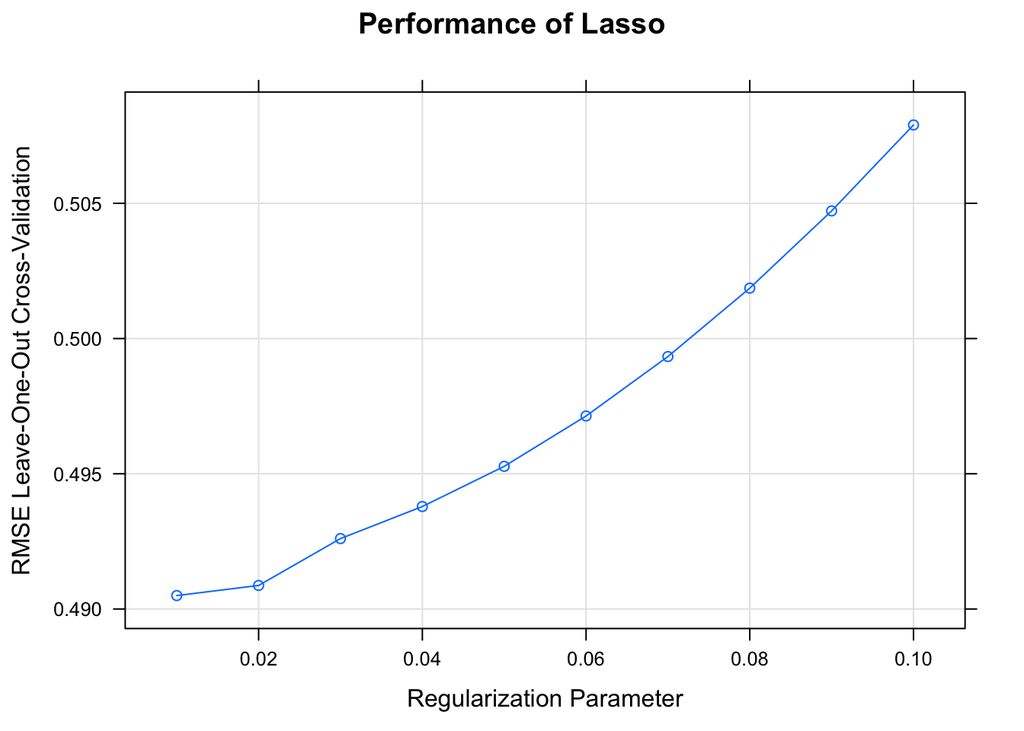

```r
plot(model_lasso, main = 'Performance of Lasso')
```

```r
options(max.print=1000000)
coef(model_lasso$finalModel)
```

```
##    [[ suppressing 71 column names 's0', 's1', 's2' ... ]]
```

```r
cat(sprintf('Best Lasso Model'))
cat(sprintf('Model: pH ~ %s\n\n',
            paste(model_lasso$finalModel$xNames,
                  collapse = ' + ')))
```

```
## 16 x 71 sparse Matrix of class "dgCMatrix"
##
## (Intercept) 6.757088 6.73832745  6.7304634  6.7399915  6.748673  6.7565837
## Temp        .        .           .          .          .         .
## Cond        .        .           .          .          .         .
## Ca          .        .           .          .          .         .
## Mg          .        .           .          .          .         .
## Na          .        .           .          .          .         .
## K           .        .           .          .          .         .
## AlkAcid     .        0.05842434  0.1089857  0.1502216  0.187794  0.2220286
## SO4_IC      .        .           .          .          .         .
## Cl          .        .           .          .          .         .
## NO2NO3N     .        .           .          .          .         .
## Tot.N_ps    .        .           .          .          .         .
## TotP        .        .           .          .          .         .
## AbsF420nm   .        .          -0.0451004 -0.1677616 -0.279526 -0.3813616
## TOC         .        .           .          .          .         .
## Si          .        .           .          .          .         .
##
## (Intercept)  6.7637915  6.7703589  6.7763429  6.7817953  6.7867633  6.7912900
## Temp         .          .          .          .          .          .
## Cond         .          .          .          .          .          .
## Ca           .          .          .          .          .          .
## Mg           .          .          .          .          .          .
## Na           .          .          .          .          .          .
## K            .          .          .          .          .          .
## AlkAcid      0.2532219  0.2816441  0.3075413  0.3311379  0.3526382  0.3722285
## SO4_IC       .          .          .          .          .          .
## Cl           .          .          .          .          .          .
## NO2NO3N      .          .          .          .          .          .
## Tot.N_ps     .          .          .          .          .          .
## TotP         .          .          .          .          .          .
## AbsF420nm   -0.4741504 -0.5586961 -0.6357310 -0.7059223 -0.7698780 -0.8281520
## TOC          .          .          .          .          .          .
## Si           .          .          .          .          .          .
##
## (Intercept)  6.7954145  6.7991726  6.8025969  6.8057169  6.8085598  6.8111501
## Temp         .          .          .          .          .          .
## Cond         .          .          .          .          .          .
## Ca           .          .          .          .          .          .
```

[output cut: 219 more lines]

```
## Cond        -1.753516e-04 -1.751926e-04
## Ca           5.426288e-01  5.427350e-01
## Mg           7.986303e-01  7.992577e-01
## Na          -1.478383e-01 -1.480408e-01
## K            1.676134e+00  1.676522e+00
## AlkAcid      .            -2.220304e-04
## SO4_IC      -7.454942e-01 -7.458491e-01
## Cl          -2.287527e-02 -2.287712e-02
## NO2NO3N      2.401226e-04  2.405572e-04
## Tot.N_ps     7.254851e-05  7.278204e-05
## TotP        -1.505232e-03 -1.508656e-03
## AbsF420nm   -1.736910e+00 -1.737706e+00
## TOC          2.089352e-03  2.108457e-03
## Si           4.801177e-02  4.806894e-02
## Best Lasso ModelModel: pH ~ Temp + Cond + Ca + Mg + Na + K + AlkAcid + SO4_IC + Cl + NO2NO3N + Tot.N_ps + TotP + AbsF420nm + TOC + Si
```

2. Prediction In the next task you will investigate the correlations between the predictors. As you can see there are some highly correlated variables. Extract the CV error from the LASSO in a. Find a method that is known to produce low prediction error on correlated data. The method should give at least as good prediction error as the LASSO. Motivate your choice and present details on how you have tuned the method. (5p)

```r
# Best Lasso MSE
lasso_mse = min(model_lasso$results$RMSE ** 2)
cat(sprintf("\nLasso MSE: %.3f \n\n", lasso_mse))
```

```
##
## Lasso MSE: 0.241
```

**Using PLS**

```r
model_pls <- train(
  pH~., data = lake, method = "pls",
  scale = TRUE, # scale = TRUE for standardizing the variables to make them comparable.
  trControl = trainControl("LOOCV", number = 500),
  tuneLength = 50
  )
```

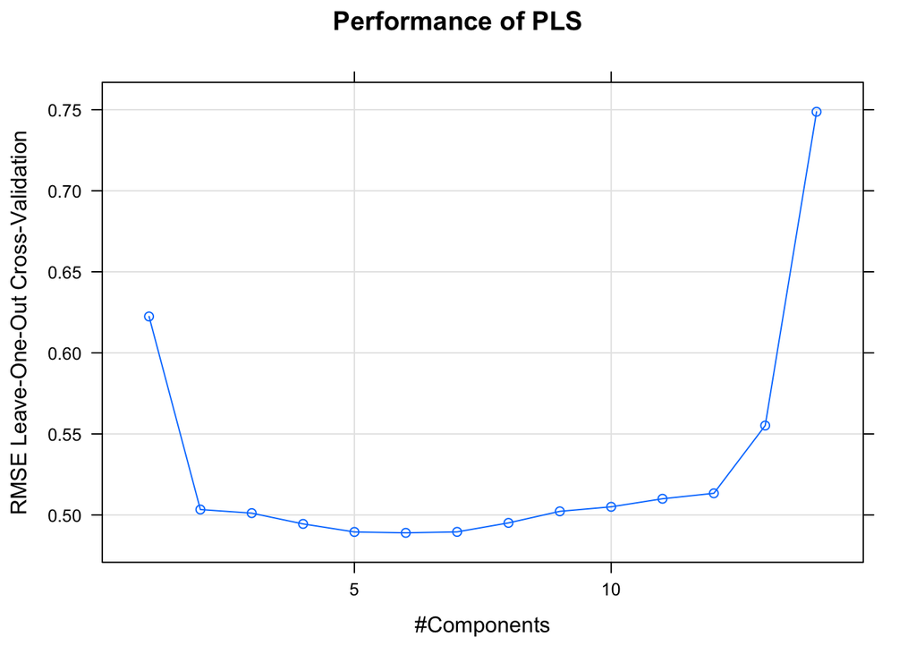

```r
# Plot model RMSE vs different values of components
plot(model_pls, main = 'Performance of PLS')
```

```r
# minimize the cross-validation error, RMSE
pls_mse = min(model_pls$results$RMSE ** 2)
cat(sprintf("\nPLS MSE: %.3f \n\n", pls_mse))
```

```
##
## PLS MSE: 0.239
```

I chose PLS because easy of the implemention, tuning and remembering it’s good performance from the exercises. However it didn’t increase the performance and the mse remained in one decimal place. Just give reasonable tune length and it finds the best tune. Also this method is not so time consuming.

## Assignment 2. Nonlinear regression

File Concrete_Data_2.xls contains three variables. The Concrete Strength which is a possibly nonlinear function of Age and amount of Cement.

```r
library(readxl)
concrete<- read_excel("Concrete_Data_2.xls")
col_names_ = c('Cement', 'Age', 'Strength')
colnames(concrete) = col_names_
str(concrete)
```

```
## tibble [1,030 × 3] (S3: tbl_df/tbl/data.frame)
##  $ Cement  : num [1:1030] 540 540 332 332 199 ...
##  $ Age     : num [1:1030] 28 28 270 365 360 90 365 28 28 28 ...
##  $ Strength: num [1:1030] 80 61.9 40.3 41.1 44.3 ...
```

```r
summary(concrete)
```

```
##      Cement           Age            Strength
##  Min.   :102.0   Min.   :  1.00   Min.   : 2.332
##  1st Qu.:192.4   1st Qu.:  7.00   1st Qu.:23.707
##  Median :272.9   Median : 28.00   Median :34.443
##  Mean   :281.2   Mean   : 45.66   Mean   :35.818
##  3rd Qu.:350.0   3rd Qu.: 56.00   3rd Qu.:46.136
##  Max.   :540.0   Max.   :365.00   Max.   :82.599
```

```r
anyNA.data.frame(concrete)
```

```
## [1] FALSE
```

1. GAM Import the data to R and fit two GAM models (with both Spline and Loess smoothers) using Concrete Strength as response variable, and Age and Cement as predictors. Use leave-one-out-cross-validation as model selection criterion to determine which model fits best. Explain the results and provide plots of the regression functions for the best model. (5p)

**GAM Spline**

```r
library(gam)
library(caret)
# Build the GAM model based on splines and find best model with LOOCV
fit_gam_spline <- train(
  Strength~., data = concrete, method = "gamSpline",
  scale = FALSE,
  trControl = trainControl("LOOCV", number = 1),
  tuneGrid = expand.grid(df = c(75, 100, 125)))
```

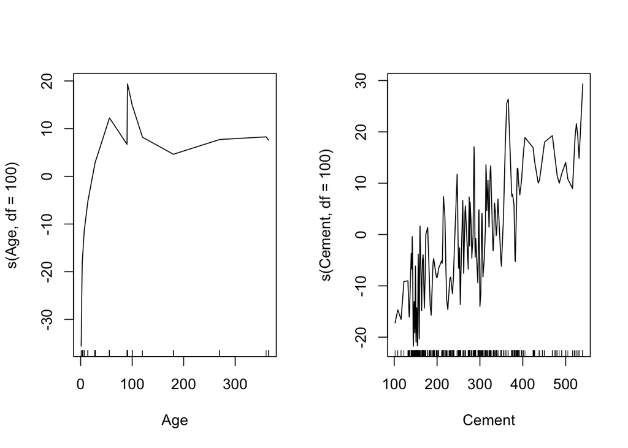

```r
fit_gam_spline
par(mfrow = c(1, 2))
plot(fit_gam_spline$finalModel)
```

```r
cat(sprintf('GAM Split best model RMSE: %.4g', min(fit_gam_spline$results$RMSE)))
```

```
## Generalized Additive Model using Splines
##
## 1030 samples
##    2 predictor
##
## No pre-processing
## Resampling: Leave-One-Out Cross-Validation
## Summary of sample sizes: 1029, 1029, 1029, 1029, 1029, 1029, ...
## Resampling results across tuning parameters:
##
##   df   RMSE      Rsquared   MAE
##    75  8.547734  0.7381295  6.578703
##   100  8.452769  0.7444472  6.444610
##   125  8.469832  0.7435983  6.449530
##
## RMSE was used to select the optimal model using the smallest value.
## The final value used for the model was df = 100.
## GAM Split best model RMSE: 8.453
```

Best model is reached when degrees of freedom is 100. This gives us RMSE of 8.45.

**GAM Loess**

```r
# Build the GAM model based on splines and find best model with LOOCV
library(gam)
library(dplyr)
seq_lenght = 6

#fit_gam_loess = lo(Strength~., data = concrete, span = 0.3)

#fit_gam_loess <- train(
#  Strenght~., data=concrete, method = "gamLoess",
#  trControl = trainControl("LOOCV", number = 1),
#  tuneGrid = expand.grid(span = seq(0.1, 0.6, length = seq_lenght),
#                         degree = c(rep(1,seq_lenght))))
```

```r
#fit_gam_loess
#par(mfrow = c(1,2))
#plot(fit_gam_loess$finalModel)
#cat(sprintf('GAM Loess best model RMSE: %.4g', min(fit_gam_loess$results$RMSE)))
```

I couldn’t run this. Probably enviroment error?

2. Thin-plate spline Fit a thin-plate spline model to the Concrete data using the same response and predictors as in a. Provide model results and a contour fit plot of the best fitting model. What is the methodological difference compared to a. and how did you tune the model? (5p)

```r
library(fields)

concrete_x = subset(concrete, select = -c(Strength))
concrete_y = concrete$Strength

tpsfit <- Tps(concrete_x, concrete_y, scale.type="unscaled", GCV = TRUE)
```

```r
summary(tpsfit)
```

```
## CALL:
## Tps(x = concrete_x, Y = concrete_y, scale.type = "unscaled",
##     GCV = TRUE)
##
##  Number of Observations:                1030
##  Number of unique points:               775
##  Number of parameters in the null space 3
##  Parameters for fixed spatial drift     3
##  Effective degrees of freedom:          50.6
##  Residual degrees of freedom:           979.4
##  MLE sigma                              9.143
##  GCV sigma                              9.807
##  Pure error sigma                       7.831
##  MLE rho                                0.1825
##  Scale passed for covariance (rho)      <NA>
##  Scale passed for nugget (sigma^2)      <NA>
##  Smoothing parameter lambda             457.9
##
## Residual Summary:
##      min    1st Q   median    3rd Q      max
## -30.2700  -6.6560  -0.6884   6.0020  40.3400
##
## Covariance Model: Rad.cov
##   Names of non-default covariance arguments:
##        p
##
## DETAILS ON SMOOTHING PARAMETER:
##  Method used:   GCV    Cost:  1
##    lambda       trA       GCV   GCV.one GCV.model      shat
##   457.905    50.608   186.214   101.145   177.346     9.807
##
##  Summary of all estimates found for lambda
##              lambda    trA    GCV  shat -lnLike Prof converge
## GCV        457.9050  50.61 186.21 9.807         2964        7
## GCV.model   17.0709 158.27 169.35 8.875           NA        3
## GCV.one      7.2553 203.35  92.67 8.624           NA        4
## RMSE             NA     NA     NA    NA           NA       NA
## pure error   0.6204 369.45 341.15 7.831         3171       NA
## REML       153.5745  76.36 187.57 9.510         2959        8
```

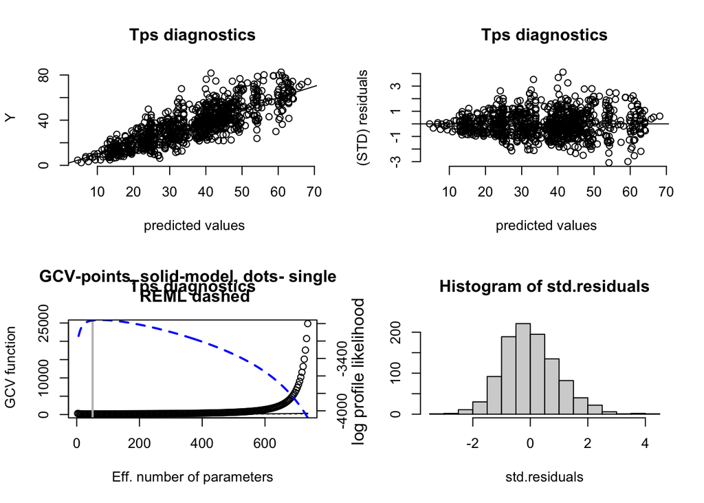

```r
par(mfrow = c(2,2))
plot(tpsfit, main = 'Tps diagnostics')
```

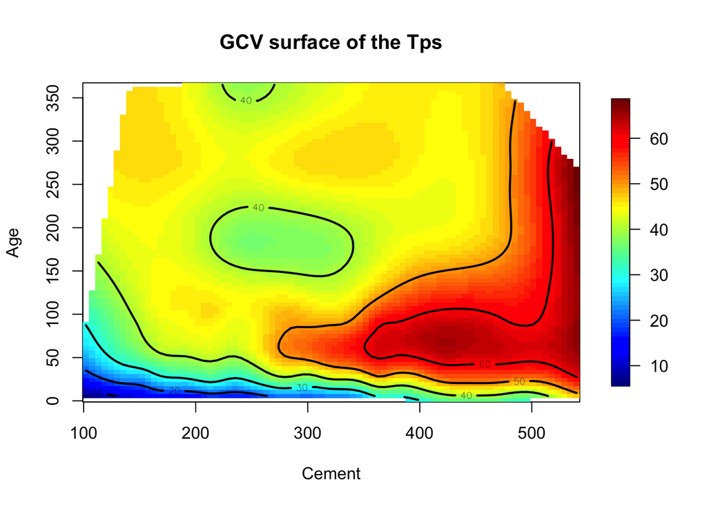

```r
par(mfrow = c(1,1))
surface(tpsfit, main = 'GCV surface of the Tps')
```

```r
look = predict(tpsfit)
tps_mse = sqrt(mean((concrete_y - look) ** 2))
cat(sprintf("TPS MSE: %.3f", tps_mse))
```

```
## TPS MSE: 9.563
```

The main difference is that general additive models allow non-linear functions compared to splines. Polynomials are very restricted form of a curve even when they are form of a plane. Overall GMA models fits ‘better’ to shape of the data where spline models even thin-plate are limited to form of the polynomials.

## Assignment 3. Classification

The file ‘olives.csv’ contains data about the content of fatty acids in samples of olive oil from three regions and nine different areas in Italy.

```r
olive = read.csv('olive.csv', header = T)
olive$Region = as.factor(olive$Region)
olive_sub = subset(olive, select = -c(Area, Sample))
str(olive_sub)
```

```
## 'data.frame':    572 obs. of  9 variables:
##  $ Region     : Factor w/ 3 levels "1","2","3": 1 1 1 1 1 1 1 1 1 1 ...
##  $ palmitic   : int  1075 1088 911 966 1051 911 922 1100 1082 1037 ...
##  $ palmitoleic: int  75 73 54 57 67 49 66 61 60 55 ...
##  $ stearic    : int  226 224 246 240 259 268 264 235 239 213 ...
##  $ oleic      : int  7823 7709 8113 7952 7771 7924 7990 7728 7745 7944 ...
##  $ linoleic   : int  672 781 549 619 672 678 618 734 709 633 ...
##  $ linolenic  : int  36 31 31 50 50 51 49 39 46 26 ...
##  $ arachidic  : int  60 61 63 78 80 70 56 64 83 52 ...
##  $ eicosenoic : int  29 29 29 35 46 44 29 35 33 30 ...
```

```r
summary(olive_sub)
```

```
##  Region     palmitic     palmitoleic        stearic          oleic
##  1:323   Min.   : 610   Min.   : 15.00   Min.   :152.0   Min.   :6300
##  2: 98   1st Qu.:1095   1st Qu.: 87.75   1st Qu.:205.0   1st Qu.:7000
##  3:151   Median :1201   Median :110.00   Median :223.0   Median :7302
##          Mean   :1232   Mean   :126.09   Mean   :228.9   Mean   :7312
##          3rd Qu.:1360   3rd Qu.:169.25   3rd Qu.:249.0   3rd Qu.:7680
##          Max.   :1753   Max.   :280.00   Max.   :375.0   Max.   :8410
##     linoleic        linolenic       arachidic       eicosenoic
##  Min.   : 448.0   Min.   : 0.00   Min.   :  0.0   Min.   : 1.00
##  1st Qu.: 770.8   1st Qu.:26.00   1st Qu.: 50.0   1st Qu.: 2.00
##  Median :1030.0   Median :33.00   Median : 61.0   Median :17.00
##  Mean   : 980.5   Mean   :31.89   Mean   : 58.1   Mean   :16.28
##  3rd Qu.:1180.8   3rd Qu.:40.25   3rd Qu.: 70.0   3rd Qu.:28.00
##  Max.   :1470.0   Max.   :74.00   Max.   :105.0   Max.   :58.00
```

**a. Linear Discriminant Analysis**

Load the data and check for missing values and correlated predictors. Delete the Sample and Area variables. Scale the numeric variables. Divide the data randomly into 70% train and 30% test using a seed of 3. Make a linear discriminant analysis (LDA) using the lda() function. Perform predictions based on the test data and calculate the accuracy. Present a plot of the classification result that clearly shows how the test predictions relate to the training predictions including decision boundaries. (5p)

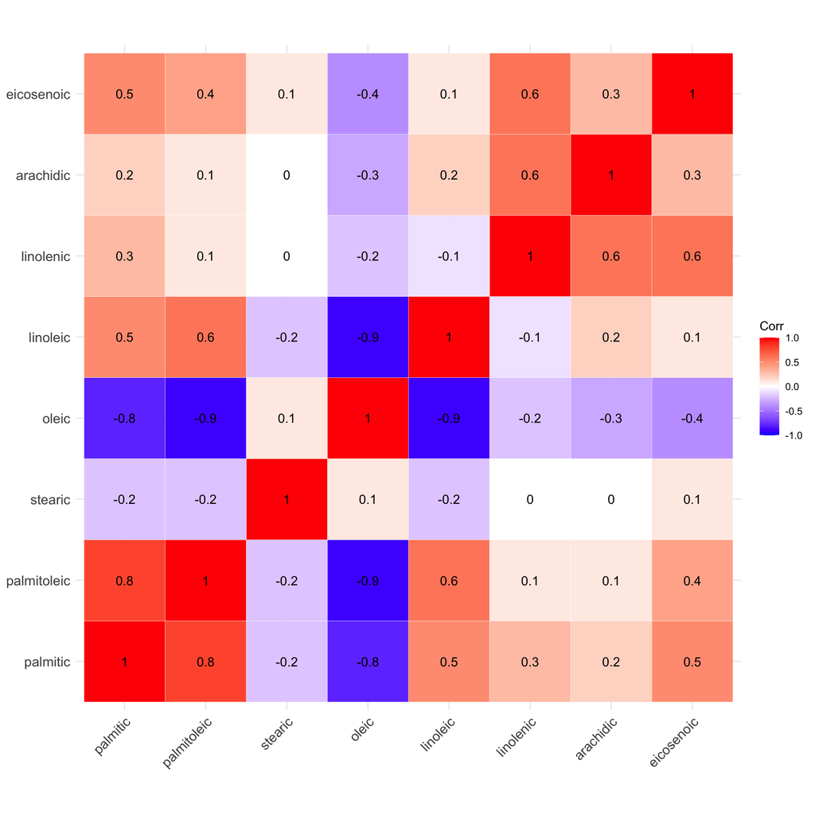

```r
library(ggcorrplot)

# Scaling
olive_sub[, -1] = scale(olive_sub[, -1])
cat(sprintf("\n Is there NA values?: %s \n", any(is.na(olive_sub))))

corr = round(cor(olive_sub[, -1]), 1)
ggcorrplot(corr, outline.color = "white",lab = T,lab_size =4)
```

```r
# Train / Test
smp_size <- floor(0.70 * nrow(olive_sub))
set.seed(2707)
train_ind <- sample(seq_len(nrow(olive_sub)), size = smp_size)

train <- olive_sub[train_ind, ]
test <- olive_sub[-train_ind, ]

summary(olive_sub)
```

```
##
##  Is there NA values?: FALSE
##  Region     palmitic        palmitoleic         stearic
##  1:323   Min.   :-3.6878   Min.   :-2.1163   Min.   :-2.0919
##  2: 98   1st Qu.:-0.8111   1st Qu.:-0.7304   1st Qu.:-0.6495
##  3:151   Median :-0.1823   Median :-0.3066   Median :-0.1596
##          Mean   : 0.0000   Mean   : 0.0000   Mean   : 0.0000
##          3rd Qu.: 0.7608   3rd Qu.: 0.8221   3rd Qu.: 0.5480
##          Max.   : 3.0918   Max.   : 2.9318   Max.   : 3.9770
##      oleic             linoleic         linolenic          arachidic
##  Min.   :-2.49316   Min.   :-2.1933   Min.   :-2.45885   Min.   :-2.6372
##  1st Qu.:-0.76821   1st Qu.:-0.8640   1st Qu.:-0.45403   1st Qu.:-0.3676
##  Median :-0.02279   Median : 0.2038   Median : 0.08574   Median : 0.1317
##  Mean   : 0.00000   Mean   : 0.0000   Mean   : 0.00000   Mean   : 0.0000
##  3rd Qu.: 0.90745   3rd Qu.: 0.8246   3rd Qu.: 0.64477   3rd Qu.: 0.5403
##  Max.   : 2.70632   Max.   : 2.0160   Max.   : 3.24720   Max.   : 2.1290
##    eicosenoic
##  Min.   :-1.08508
##  1st Qu.:-1.01407
##  Median : 0.05102
##  Mean   : 0.00000
##  3rd Qu.: 0.83209
##  Max.   : 2.96227
```

```r
library(MASS)
olive_lda = lda(Region~., data = train)
lda_predict = predict(olive_lda, test)

lda_acc = sum(test$Region == lda_predict$class)/length(test$Region) * 100

cat(sprintf("\nLDA Acc: %.2f\n\n", lda_acc))
```

```
##
## LDA Acc: 98.84
```

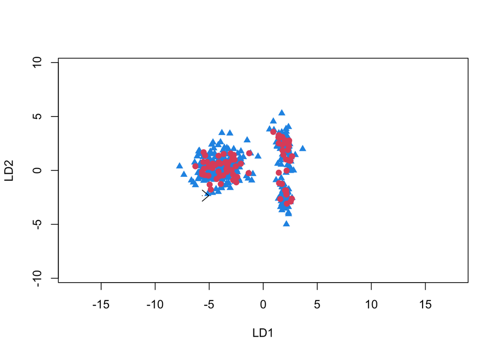

```r
n = length(olive_sub)
p.x = seq(from = min(lda_predict$x[,1]), to = max(lda_predict$x[,1]), length.out = n)
p.y = seq(from = min(lda_predict$x[,2]), to = max(lda_predict$x[,2]), length.out = n)

# notice I don't use t.lda for first variable
plot(olive_lda, panel = function(x, y, ...) { points(x, y, ...) },
     col = c(4,2,3)[factor(olive_sub$Region)],
     pch = c(17,19,15)[factor(olive_sub$Region)],
     ylim=c(-10,10), xlim=c(-10,10))

contour(x = p.x, y = p.y, z = matrix(as.numeric(lda_predict$class), nrow = n, ncol = n),
        levels = c(1, 2, 3), add = TRUE, drawlabels = FALSE)
```

2. Random Forest Use the same data as in a. and implement a Random Forest analysis via the caret package. Use LOOCV for tuning of the mtry parameter with values c(3,5,7) while you fix the number of trees to 500 and node size to 3. Present a Variable Importance plot and the test accuracy that should be calculated on the test data. Compare with a. and discuss your results. (5p)

```r
library(caret)
library(randomForest)
control <- trainControl(method='LOOCV',
                        number=500)

str(train)
```

```
## 'data.frame':    400 obs. of  9 variables:
##  $ Region     : Factor w/ 3 levels "1","2","3": 3 3 1 3 1 1 1 1 1 2 ...
##  $ palmitic   : num  -1.019 -0.781 0.642 -0.307 0.138 ...
##  $ palmitoleic: num  -0.688 -1.354 -0.23 -0.878 -0.44 ...
##  $ stearic    : num  2.208 -0.84 -1.085 -0.241 -0.16 ...
##  $ oleic      : num  1.3264 1.4619 0.0622 1.1785 0.2051 ...
##  $ linoleic   : num  -1.197 -1.567 -0.661 -1.238 -0.546 ...
##  $ linolenic  : num  -2.46 0.24 1.24 -1.69 1.17 ...
##  $ arachidic  : num  -2.6372 -0.3676 0.631 -0.8215 -0.0952 ...
##  $ eicosenoic : num  -1.014 -0.943 0.335 -1.085 0.974 ...
```

```r
#Number randomely variable selected is mtry
mtry <- c(3, 5, 7)
tunegrid <- expand.grid(.mtry=mtry)
rf_model <- train(Region~.,
                  data=train,
                  importance = TRUE,
                  metric = "Accuracy",
                  tuneGrid=tunegrid,
                  trControl=control,
                  nodesize=3)
```

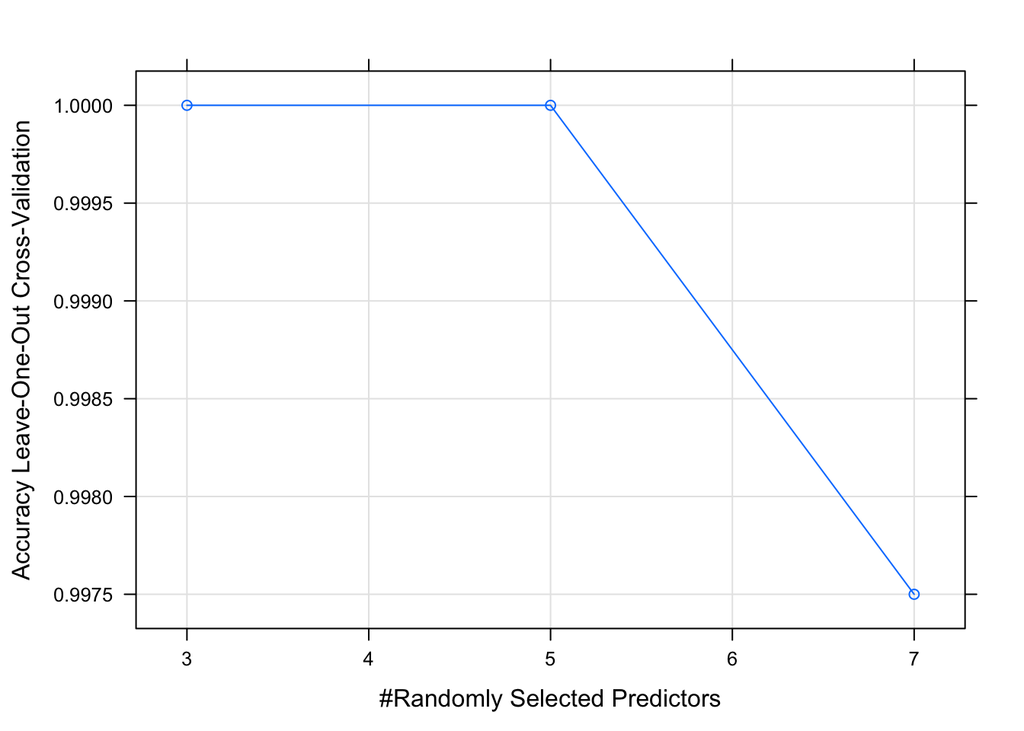

```r
rf_model$finalModel$importance
plot(rf_model)
```

```r
rf_predict = predict(rf_model, test)

rf_acc = sum(test$Region == rf_predict)/length(test$Region) * 100
cat(sprintf("\nLDA Acc (on test data): %.2f\n\n", rf_acc))
```

```
##                       1          2           3 MeanDecreaseAccuracy
## palmitic    0.071764981 0.14522545 0.036730828          0.075507960
## palmitoleic 0.039887029 0.06841219 0.030868675          0.042464895
## stearic     0.001818879 0.01092453 0.003948126          0.003934104
## oleic       0.026428498 0.17250865 0.290928683          0.121485745
## linoleic    0.011731588 0.24366781 0.204157740          0.103252992
## linolenic   0.012437526 0.02945731 0.016493054          0.016415775
## arachidic   0.011308922 0.03431637 0.031223548          0.020744890
## eicosenoic  0.313310342 0.36356776 0.426685291          0.351060930
##             MeanDecreaseGini
## palmitic           36.387088
## palmitoleic        15.643302
## stearic             1.967595
## oleic              41.083409
## linoleic           31.694094
## linolenic           8.165330
## arachidic          12.325019
## eicosenoic         85.723649
##
## LDA Acc (on test data): 100.00
```

RF perfoms with accuracy of 100% and the best model is when mtry has value of 3. LDA accuracy is 98.84 % which is top notch also. LDA is very quick to calculate and much simpler method overall. For example if you are building classification APIs and you need to update your models time to time when you are inquiring new data LDA model can be updated almost instantly but random forest needs back end calculations specially with big datasets. If you are not time critical you should use random forest based on this exercise.